# Домашняя работа про болезнь Паркинсона

Панюшев Николай

April 15, 2016

Задача. Постройте две регресионные модели для предсказания целевых переменных motor_UPDRS и total_UPDRS.

Импортируем данные:

```r
Parkinsons_data <- read.csv("http://archive.ics.uci.edu/ml/machine-learning-databases/parkinsons/telemonitoring/parkinsons_updrs.data")
```

Проверим, есть ли переменные с крайне выраженной мультиколлинеарностью. Возьму для этого функцию из предыдущей домашки!

```r
high_corr <- function(data_frame){
  correlations <- cor(data_frame[sapply(data_frame, is.numeric)],
                    use = "pairwise.complete.obs",
                    method = "pearson") # корреляции всех со всеми
  correlations <- as.data.frame(correlations)
  correlations[lower.tri(correlations, diag = T)] <- NA # выкинули главную диагональ
  var1 <- correlations[correlations > 0.75 | correlations  < (-0.75)]
  var1 <- var1[!is.na(var1)] # выделили только выдающиеся корреляции
  corr.names <- names(correlations)
  result <- matrix(ncol=3, dimnames = list(NULL, c('Var1', 'Var2', 'Correlation')))

  for (i in var1){
    tmp <- which(correlations == i, arr.ind = T, useNames = F)
    tmp <- as.vector(tmp)
    result <- rbind(c(corr.names[tmp], i), result)
    }
  return(result)
}
print(high_corr(Parkinsons_data))
```

```
##       Var1            Var2            Correlation
##  [1,] "HNR"           "PPE"           "-0.758722205915394"
##  [2,] "Jitter.Abs."   "PPE"           "0.787852839658894"
##  [3,] "Shimmer.DDA"   "HNR"           "-0.780696295044317"
##  [4,] "Shimmer.APQ11" "HNR"           "-0.777974346654104"
##  [5,] "Shimmer.APQ5"  "HNR"           "-0.790638216355629"
##  [6,] "Shimmer.APQ3"  "HNR"           "-0.780696889514637"
##  [7,] "Shimmer.dB."   "HNR"           "-0.802496461498893"
##  [8,] "Shimmer"       "HNR"           "-0.801416001873384"
##  [9,] "Shimmer.APQ5"  "NHR"           "0.79817314804109"
## [10,] "Shimmer.dB."   "NHR"           "0.798076972310196"
## [11,] "Shimmer"       "NHR"           "0.795158484922053"
## [12,] "Jitter.DDP"    "NHR"           "0.792377310038092"
## [13,] "Jitter.PPQ5"   "NHR"           "0.864864252276489"
## [14,] "Jitter.RAP"    "NHR"           "0.792372728413361"
```

[output cut: 28 more lines]

Ой вей, как же все плохо! Посмотрим, что переменные означают:

```r
ATTRIBUTE INFORMATION:

age - Subject age
sex - Subject gender '0' - male, '1' - female
test_time - Time since recruitment into the trial. The integer part is the
number of days since recruitment.
motor_UPDRS - Clinician's motor UPDRS score, linearly interpolated
total_UPDRS - Clinician's total UPDRS score, linearly interpolated
Jitter(%),Jitter(Abs),Jitter:RAP,Jitter:PPQ5,Jitter:DDP - Several measures of
variation in fundamental frequency
Shimmer,Shimmer(dB),Shimmer:APQ3,Shimmer:APQ5,Shimmer:APQ11,Shimmer:DDA -
Several measures of variation in amplitude
NHR,HNR - Two measures of ratio of noise to tonal components in the voice
RPDE - A nonlinear dynamical complexity measure
DFA - Signal fractal scaling exponent
PPE - A nonlinear measure of fundamental frequency variation
```

Ага, видим, что из Shimmer и Jitter - можно оставить по одной переменной

```r
Parkinsons_data$Jitter <- Parkinsons_data$Jitter.Abs.
Parkinsons_data[grepl('^Jitter.', names(Parkinsons_data))] <- NULL
Parkinsons_data[grepl('^Shimmer.', names(Parkinsons_data))] <- NULL

#Проверим еще разок:
print(high_corr(Parkinsons_data))
```

```
##      Var1          Var2          Correlation
## [1,] "PPE"         "Jitter"      "0.787852839658894"
## [2,] "HNR"         "PPE"         "-0.758722205915394"
## [3,] "Shimmer"     "HNR"         "-0.801416001873384"
## [4,] "Shimmer"     "NHR"         "0.795158484922053"
## [5,] "motor_UPDRS" "total_UPDRS" "0.947231314131496"
## [6,] NA            NA            NA
```

Стало гораздо лучше!

Попробуем протестировать на мультиколлинеарность с помощью пакета vif. Сделаем линейную модель, где зависимая переменная - UPDRS

```r
library(car, glmnet, quietly = T)
library(glmnet, quietly = T)
fit1 <- lm(total_UPDRS ~ ., Parkinsons_data)
summary(fit1)
```

```
##
## Call:
## lm(formula = total_UPDRS ~ ., data = Parkinsons_data)
##
## Residuals:
##     Min      1Q  Median      3Q     Max
## -8.9238 -1.9975 -0.3978  1.3039 11.2160
##
## Coefficients:
##               Estimate Std. Error t value Pr(>|t|)
## (Intercept)  3.879e+00  1.048e+00   3.700 0.000218 ***
## subject.     4.240e-02  3.865e-03  10.970  < 2e-16 ***
## age          7.007e-02  5.131e-03  13.655  < 2e-16 ***
## sex         -1.686e+00  1.060e-01 -15.909  < 2e-16 ***
## test_time    2.638e-03  7.950e-04   3.318 0.000912 ***
## motor_UPDRS  1.204e+00  5.841e-03 206.120  < 2e-16 ***
## Shimmer     -1.430e+01  3.378e+00  -4.233 2.34e-05 ***
## NHR         -3.735e+00  1.509e+00  -2.475 0.013353 *
## HNR         -1.195e-01  2.239e-02  -5.340 9.65e-08 ***
## RPDE         2.000e+00  5.859e-01   3.413 0.000647 ***
## DFA         -4.167e+00  7.637e-01  -5.456 5.08e-08 ***
## PPE         -6.852e+00  8.858e-01  -7.736 1.20e-14 ***
## Jitter       1.550e+04  2.464e+03   6.290 3.40e-10 ***
## ---
## Signif. codes:  0 '***' 0.001 '**' 0.01 '*' 0.05 '.' 0.1 ' ' 1
##
## Residual standard error: 3.239 on 5862 degrees of freedom
## Multiple R-squared:  0.9086, Adjusted R-squared:  0.9084
## F-statistic:  4854 on 12 and 5862 DF,  p-value: < 2.2e-16
```

```r
#А теперь проверим, есть ли вздутые переменные
vif_score <- vif(fit1)
max(vif_score)
```

```
## [1] 5.166719
```

```r
good_data <- Parkinsons_data[, -(which.max(vif_score))]
```

Теперь сделаем линейную модельку, которая предскажет motor_UPDRS и total_UPDRS.

```r
fit_motor <- lm(motor_UPDRS ~ ., good_data)
summary_motor <- summary(fit_motor)
#Сравним, стала ли лучше моделька
fit2 <- lm(motor_UPDRS ~ ., Parkinsons_data)
summary_fit2 <- summary(fit2)
print(summary_fit2$r.squared); print(summary_motor$r.squared)
```

```
## [1] 0.9039445
```

```
## [1] 0.9039039
```

```r
#Очень мало изменился R^2! Потому что все мультиколлинеарности выкинули уже

fit_total <- lm(total_UPDRS ~ ., good_data)
summary_total <- summary(fit_total)
print(summary_total$adj.r.squared) # неплохой результат!
```

```
## [1] 0.9082894
```

А теперь опробуем лассо-регрессию на motor_UPDRS:

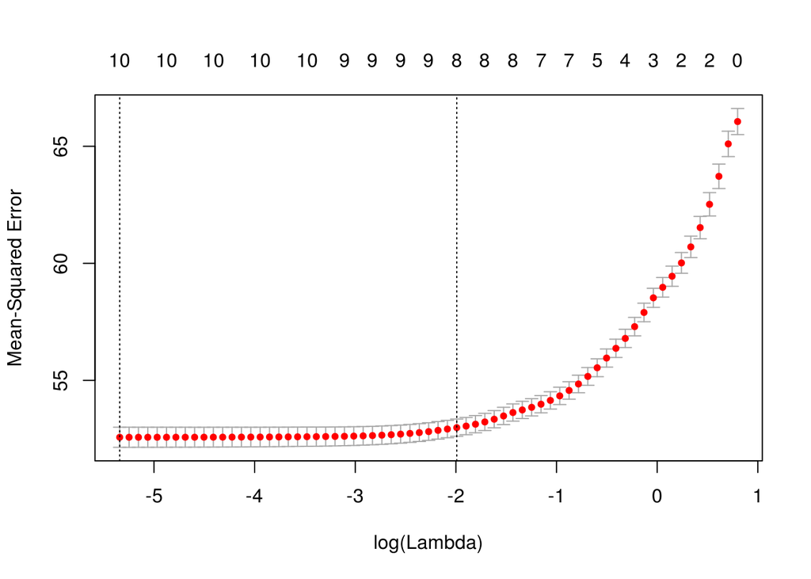

```r
Y_data <- as.matrix(good_data$motor_UPDRS)
X_data <- as.matrix(good_data[, !names(good_data) %in% c("motor_UPDRS", "total_UPDRS")])
# Не будем включать в модель total_UPDRS, потому что они с motor взаимосвязаны возможно
lambdas <-  seq(50, 0.1, length = 30) # вектор с лямбдами (величиной штрафа)
alpha = 1
m_lasso <-  glmnet(X_data, Y_data, alpha = 1, lambda = lambdas)
cv <- cv.glmnet(X_data, Y_data, alpha = 1)
plot(cv)
```

```r
motor_UPDRS_model <- coef(cv, s = "lambda.1se")
motor_UPDRS_model
```

```
## 11 x 1 sparse Matrix of class "dgCMatrix"
##                         1
## (Intercept)  1.665550e+01
## subject.     1.712805e-01
## age          2.050910e-01
## sex         -1.799803e+00
## test_time    7.638604e-03
## Shimmer      .
## HNR         -8.722804e-02
## RPDE         .
## DFA         -1.976813e+01
## PPE          1.376205e+01
## Jitter      -1.559735e+04
```

А теперь попробуем на total_UPDRS:

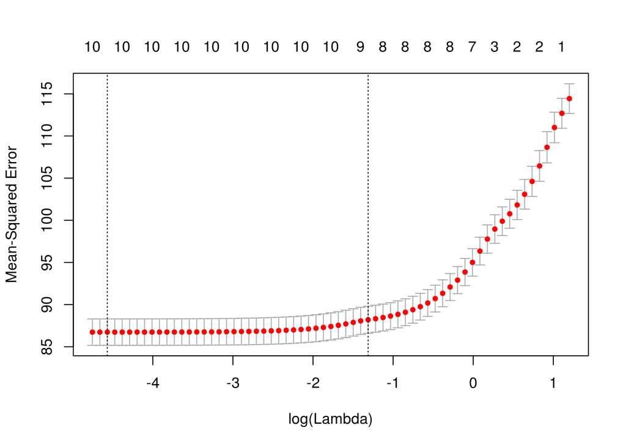

```r
Y_data <- as.matrix(good_data$total_UPDRS) #Перезапишем Y-data, X_data - прежние
# вектор с лямбдами тот же, альфа та же
m_lasso <-  glmnet(X_data, Y_data, alpha = 1, lambda = lambdas)
cv <- cv.glmnet(X_data, Y_data, alpha = 1)
plot(cv)
```

```r
total_UPDRS_model <- coef(cv, s = "lambda.1se")
total_UPDRS_model
```

```
## 11 x 1 sparse Matrix of class "dgCMatrix"
##                       1
## (Intercept)  20.0361103
## subject.      0.2389767
## age           0.3131267
## sex          -3.6349316
## test_time     0.0097755
## Shimmer       .
## HNR          -0.1214385
## RPDE          0.8407842
## DFA         -23.8834629
## PPE           7.1976093
## Jitter        .
```

Посмотрим, какие еще есть требования к моделям:

*линейная зависимость зависимой переменной от предиктора* нормальное распределение residuals *равномерная дисперсия residuals* независимость residuals

Проверим нормальность residuals - qq-plot

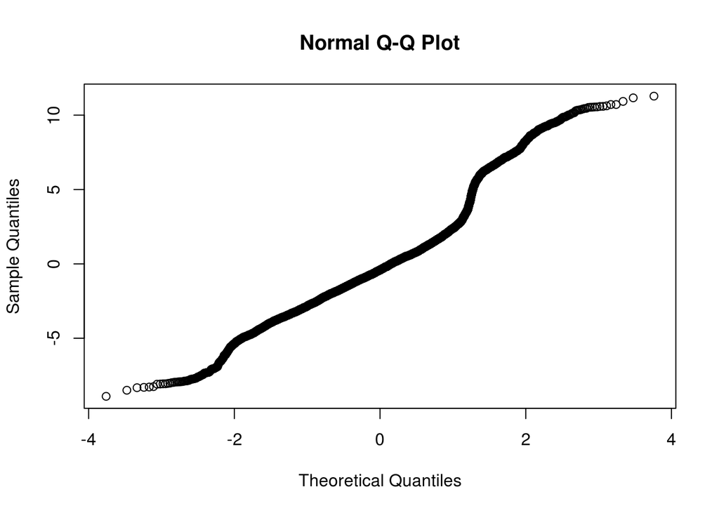

```r
qqnorm(fit_total$residuals) #для модели fit_total
```

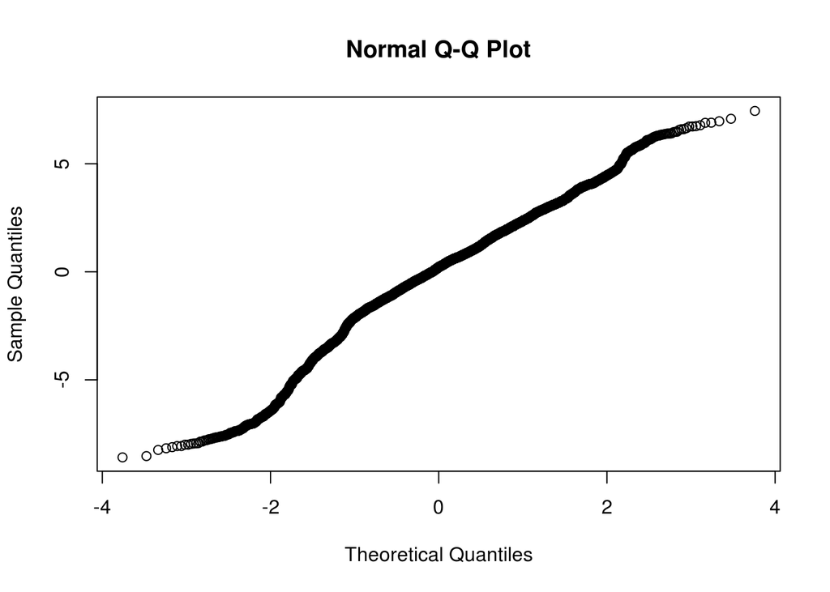

```r
qqnorm(fit_motor$residuals) #для модели fit_motor
```

```r
shapiro.test(sample(fit_total$residuals, 5000))
```

```
##
##  Shapiro-Wilk normality test
##
## data:  sample(fit_total$residuals, 5000)
## W = 0.94417, p-value < 2.2e-16
```

```r
shapiro.test(sample(fit_motor$residuals, 5000))
```

```
##
##  Shapiro-Wilk normality test
##
## data:  sample(fit_motor$residuals, 5000)
## W = 0.98019, p-value < 2.2e-16
```

и там, и там распределение остатков ненормально, а это жаль

Проверим, линейна ли зависимость переменных от предиктора

```r
library(mgcv)
fixDependence(Y_data, X_data)
```

[output not shown]

Не знаю, есть ли смысл какой-то еще проверять дальше(